# About me

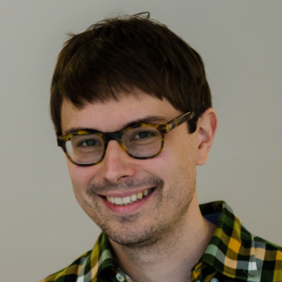

I am Martin Papenberg, working as a post-doc researcher at the the department of [Psychological Assessment and Differential Psychology](http://www.psychologie.hhu.de/en/research-teams/%20psychological-assessment-and-differential-psychology.html) at [Heinrich Heine University Düsseldorf](https://www.uni-duesseldorf.de/home/en/home.html). I am interested in measurement, personality[^1] and programming[^2], among others.

Currently, I am primarily working on the `R` package [`anticlust`](https://github.com/m-Py/anticlust) package that enables the automatic selection of stimuli for psychological experiments. Check out my latest preprint on the anticlustering method: [Using anticlustering to partition a stimulus pool into equivalent parts](https://psyarxiv.com/3razc/).

### Preprints

Papenberg, M., & Klau, G. W. (2019, October 30). Using anticlustering to partition a stimulus pool into equivalent parts. https://doi.org/10.31234/osf.io/3razc. Submitted for publication.

### Journal publications

Papenberg, M., Diedenhofen, B., & Musch, J. (2019). An experimental validation of sequential multiple-choice tests. *Journal of Experimental Education*. Advance Online Publication. https://doi.org/10.1080/00220973.2019.1671299

Papenberg, M., & Musch, J. (2017). Of Small Beauties and Large Beasts: The Quality of Distractors on Multiple-Choice Tests Is More Important Than Their Quantity. *Applied Measurement in Education, 30*(4), 273–286. https://doi.org/10.1080/08957347.2017.1353987

Papenberg, M., Willing, S., & Musch, J. (2017). Sequentially Presented Response Options Prevent The Use Of Testwiseness Cues In Multiple-Choice Testing. *Psychological Test and Assessment Modeling, 59*(2), 245–266. Retrieved from http://www.psychologie-aktuell.com/fileadmin/download/ptam/2-2017_20170627/06_Papenberg_.pdf

### Other publications

Papenberg, M. (2018). *On how testwiseness and acceptance reluctance influence the validity of sequential knowledge tests* (Inaugural-Dissertation). Retrieved from https://docserv.uni-duesseldorf.de/servlets/DocumentServlet?id=46569.

Papenberg, M. (2018). Test theory in R [Testtheorie mit R]. Retrieved from https://osf.io/y4a6k/.

### Software

- [anticlust: Subset partitioning via anticlustering](https://github.com/m-Py/anticlust)
- [propint: An R package to compute interactions in proportions](https://github.com/m-Py/propint)
- [cower: An R package for power analyses of the comparison of correlations](https://github.com/m-Py/cower)
- [prmisc: An R package to print statistical results in R markdown](https://github.com/m-Py/prmisc)
- [bayesEd: An educational R package to visualize Bayes factors](https://github.com/m-Py/bayesEd)
- [BART: A JavaScript implementation of the Balloon Analogue Risk Task](https://github.com/m-Py/BART)

### Short CV

| Year |  |
| --- | --- |
| 2018 | PhD (Dr. rer. nat) at the Faculty of Mathematics and Natural Sciences, University of Düsseldorf |
| 2018 | BSc., Computer Science, University of Düsseldorf |
| Since 2014 | Research assistant at the department of Psychological Assessment and Differential Psychology, University of Düsseldorf |
| 2013 | MSc., Psychology, University of Düsseldorf |
| 2011 | BSc., Psychology, University of Düsseldorf |

### Contact

I like hearing from people!

- Send me an email
- [Twitter](https://twitter.com/MPapenberg)
- [Github](https://github.com/m-Py)
- [Google Scholar](https://scholar.google.de/citations?user=_h33JecAAAAJ&hl=de&oi=sra)
[^1]: My doctoral dissertation dealt with personality influences on test achievement, see [On how testwiseness and acceptance reluctance influence the validity of sequential knowledge tests](https://docserv.uni-duesseldorf.de/servlets/DocumentServlet?id=46569).
[^2]: For example, I wrote an introduction to the statistical programming language [R](https://cran.r-project.org/), [available for free here](https://osf.io/nghyv/) (in German language).